# Udacity Diamonds Exercise

Jonathan Morken

February 15, 2016

The following is my full notes/results from performing the Udacity Diamonds Promblem set.

### Section One - Answers to introductory questions:

There are 53940 observations and 10 variables as can be seen with the str f(x). 3 of the variables are ordered factors.

```
## Classes 'tbl_df', 'tbl' and 'data.frame':    53940 obs. of  10 variables:
##  $ carat  : num  0.23 0.21 0.23 0.29 0.31 0.24 0.24 0.26 0.22 0.23 ...
##  $ cut    : Ord.factor w/ 5 levels "Fair"<"Good"<..: 5 4 2 4 2 3 3 3 1 3 ...
##  $ color  : Ord.factor w/ 7 levels "D"<"E"<"F"<"G"<..: 2 2 2 6 7 7 6 5 2 5 ...
##  $ clarity: Ord.factor w/ 8 levels "I1"<"SI2"<"SI1"<..: 2 3 5 4 2 6 7 3 4 5 ...
##  $ depth  : num  61.5 59.8 56.9 62.4 63.3 62.8 62.3 61.9 65.1 59.4 ...
##  $ table  : num  55 61 65 58 58 57 57 55 61 61 ...
##  $ price  : int  326 326 327 334 335 336 336 337 337 338 ...
##  $ x      : num  3.95 3.89 4.05 4.2 4.34 3.94 3.95 4.07 3.87 4 ...
##  $ y      : num  3.98 3.84 4.07 4.23 4.35 3.96 3.98 4.11 3.78 4.05 ...
##  $ z      : num  2.43 2.31 2.31 2.63 2.75 2.48 2.47 2.53 2.49 2.39 ...
```

### Section Two - Create a histogram of the price of all the diamonds in the diamond data set:

You will note the shape of the curve. It is non-normal with a rather long tail. Basic statistics appear below the graph:

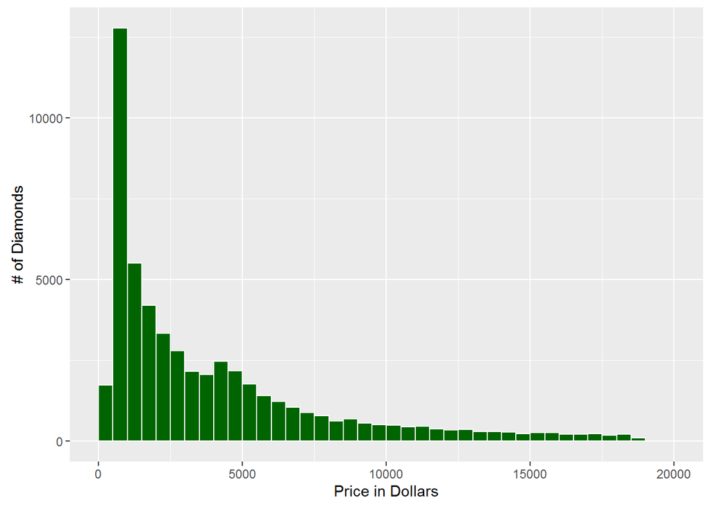

**Note that the above receives a warning message that R Removed 2 rows containing missing values (geom_bar); however, I have looked for nulls and NAs throughout the dataset to no avail. What am I missing?

| Summary Stats | # |
| --- | --- |
| Median | 2401 |
| Mean | 3932.8 |
| Skewness | 1.62 |
| Kurtosis | 5.18 |

### Section Three - Answers to Diamond Count Questions:

How many diamonds cost less than $500: 1729  
How many diamonds cost less than $250: 0  
How many diamonds cost $15,000 or more: 1656

### Section Four - Exploring the Largest Peak in the Histogram:

Udacity Suggestions in the order they appear below: changing the limits (Dark Green), binwidths (Green), and breaks (Light Green).

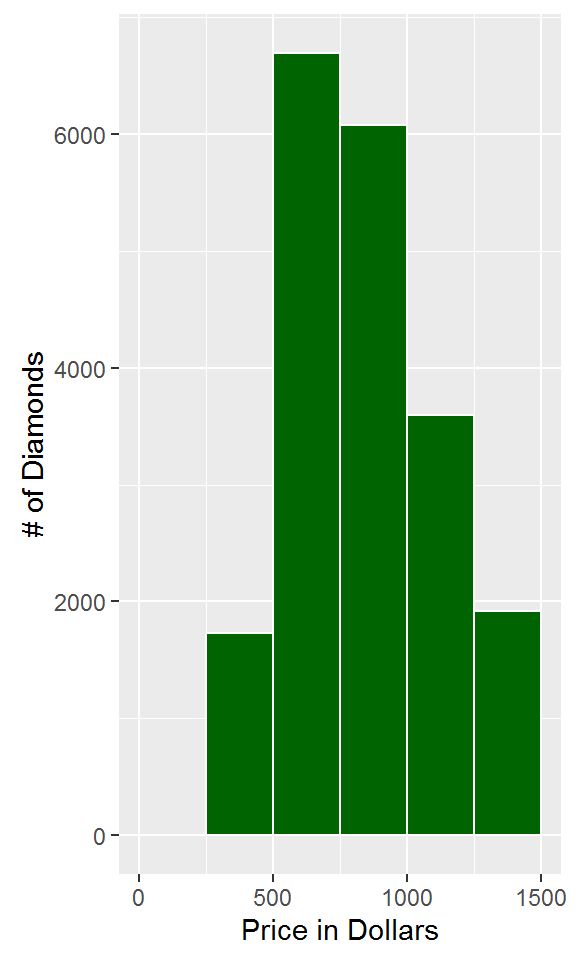

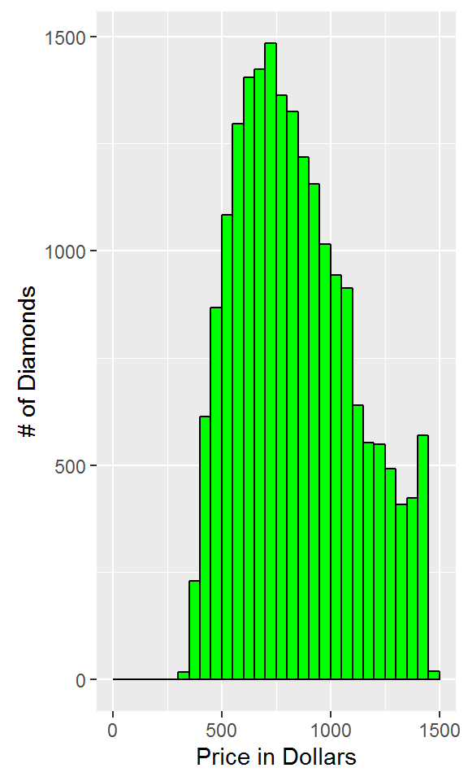

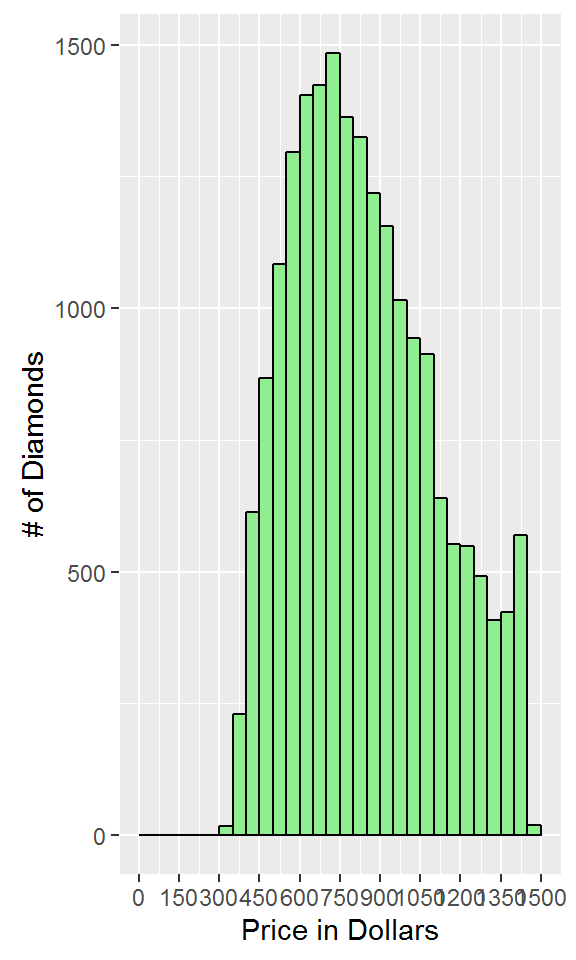

As apparent here, the most common price for diamonds is ~ $700.

### Section Five - Break out the Histogram of Prices by Cut:

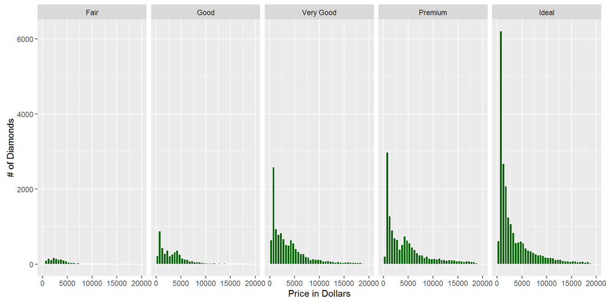

### Section Six - Answer questions by Cut:

Max followed by Min and then Median

```
## diamonds$cut: Fair
## [1] 18574
## --------------------------------------------------------
## diamonds$cut: Good
## [1] 18788
## --------------------------------------------------------
## diamonds$cut: Very Good
## [1] 18818
## --------------------------------------------------------
## diamonds$cut: Premium
## [1] 18823
## --------------------------------------------------------
## diamonds$cut: Ideal
## [1] 18806
```

```
## diamonds$cut: Fair
## [1] 337
## --------------------------------------------------------
## diamonds$cut: Good
## [1] 327
## --------------------------------------------------------
## diamonds$cut: Very Good
## [1] 336
## --------------------------------------------------------
## diamonds$cut: Premium
## [1] 326
## --------------------------------------------------------
## diamonds$cut: Ideal
## [1] 326
```

```
## diamonds$cut: Fair
## [1] 3282
## --------------------------------------------------------
## diamonds$cut: Good
## [1] 3050.5
## --------------------------------------------------------
## diamonds$cut: Very Good
## [1] 2648
## --------------------------------------------------------
## diamonds$cut: Premium
## [1] 3185
## --------------------------------------------------------
## diamonds$cut: Ideal
## [1] 1810
```

### Section Seven - add a parameter to facet_wrap so that the y-axis in the histograms is not fixed.

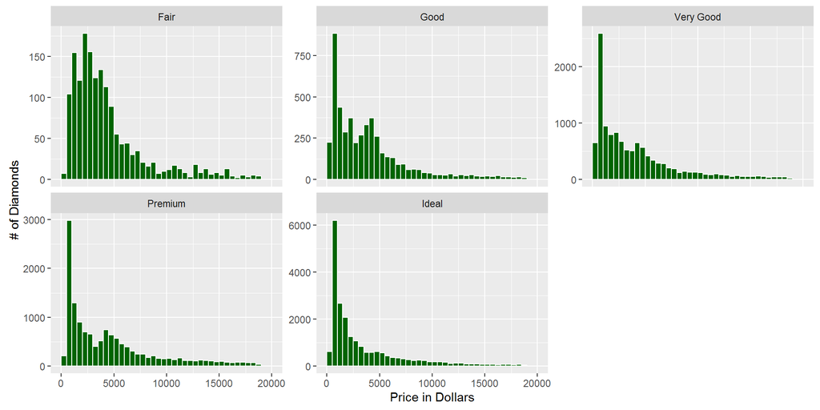